# cshea26_OriginalHomeworkCode_04

## Question 2) The dataset from Kamilar and Cooper has in it a large number of variables related to life history and body size.

- For this exercise, the end aim is to fit a simple linear regression model to predict longevity (MaxLongevity_m) measured in months from species’ brain size (Brain_Size_Species_Mean) measured in grams. Do the following for both longevity~brain size and log(longevity)~log(brain size):

## Part 1:

Fit the regression model and, using {ggplot2}, produce a scatterplot with the fitted line superimposed upon the data. Append the the fitted model equation to your plot (HINT: use the function geom_text()) reattempt:

```r
library(curl)
```

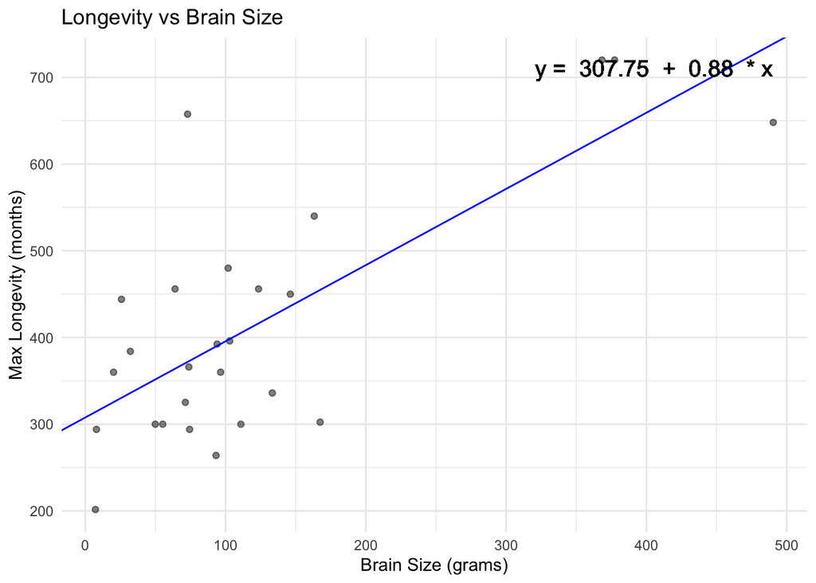

```r
library(ggplot2)
library(ggpubr)
library(gridExtra)

data <- curl("https://raw.githubusercontent.com/fuzzyatelin/fuzzyatelin.github.io/master/AN588_Fall23/KamilarAndCooperData.csv") #load data
data <- read.csv(data, header = TRUE, sep = ",", stringsAsFactors = FALSE)
data <- na.omit(data) # clean data to get longevity and brain size (NA categories)
Brain_Size_Species_Mean <- data$Brain_Size_Species_Mean

#creating model1: longevity ~ brain size
model1 <- lm(MaxLongevity_m ~ Brain_Size_Species_Mean, data = data) #coef returns standardized model regression coefficients
intercept1 <- coef(model1)["(Intercept)"]
slope1 <- coef(model1)["Brain_Size_Species_Mean"]

# creating model 2: log(longevity) ~ log(brain size), doing the same as above but with the logs
model2 <- lm(log(MaxLongevity_m) ~ log(Brain_Size_Species_Mean), data = data)
intercept2 <- coef(model2)["(Intercept)"]
slope2 <- coef(model2)["log(Brain_Size_Species_Mean)"]

#plotting model1 in ggplot as p1
p1 <- ggplot(data, aes(x = Brain_Size_Species_Mean, y = MaxLongevity_m)) +
  geom_point(alpha = 0.5) +
  geom_abline(intercept = intercept1, slope = slope1, color = "blue") + geom_text(aes(x = max(Brain_Size_Species_Mean), y = max(MaxLongevity_m),
#this next part gives me my equation for the line
                label = paste("y = ", round(coef(model1)[1], 2), " + ", round(coef(model1)[2], 2), " * x")),
            hjust = 1, vjust = 1, size = 5) +
  labs(title = "Longevity vs Brain Size", x = "Brain Size (grams)", y = "Max Longevity (months)") +  theme_minimal()
p1
```

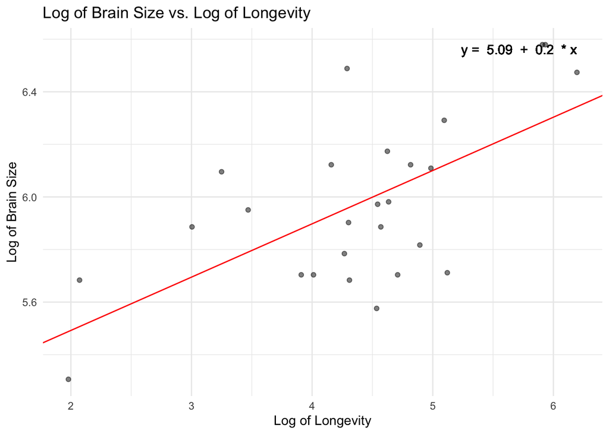

```r
#p2 represents linear regression plot for logs
p2 <- ggplot(data, aes(x = log(Brain_Size_Species_Mean), y = log(MaxLongevity_m))) +
  geom_point(alpha = 0.5) +
  geom_abline(intercept = intercept2, slope = slope2, color = "red") +
  geom_text(aes(x = max(log(Brain_Size_Species_Mean)), y = max(log(MaxLongevity_m)),
                label = paste("y = ", round(coef(model2)[1], 2), " + ", round(coef(model2)[2], 2), " * x")),
            hjust = 1, vjust = 1) +
  labs(title = "Log of Brain Size vs. Log of Longevity", x = "Log of Longevity", y = "Log of Brain Size") +
  theme_minimal()
p2
```

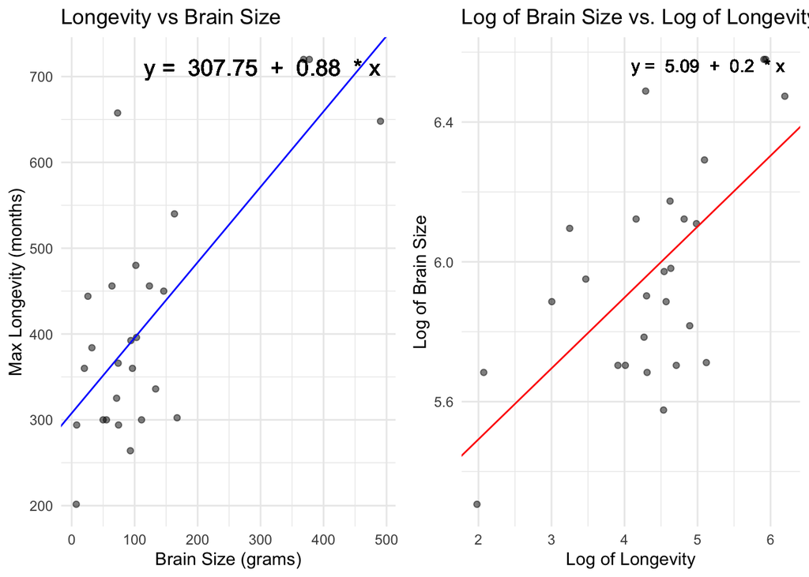

```r
grid.arrange(p1, p2, ncol = 2)
```

- tried to use geom_smooth() but didn’t like how the line it created wasn’t making contact with the x axis. is there a way to fix this while still using geom smooth? instead here i just plotted a line equal to the intercept and slope i established above with my two models

## Part 2:

Identify and interpret the point estimate of the slope (β1), as well as the outcome of the test associated with the hypotheses H0: β1 = 0; HA: β1 ≠ 0. Also, find a 90 percent CI for the slope (β1) parameter.

An equation I used to calculate beta 1: - beta1 <- cor(w, h) * (sd(h)/sd(w)) where - w <- d$weight (longevity) - h <- d$height (brain size)

```r
w <- data$MaxLongevity_m
h <- data$Brain_Size_Species_Mean
beta1 <- cor(w, h) * (sd(h)/sd(w))
beta1
```

```
## [1] 0.60885
```

```r
#to determine beta1 for the log plots
w <- log(data$MaxLongevity_m)
h <- log(data$Brain_Size_Species_Mean)
beta1 <- cor(w, h) * (sd(h)/sd(w))
beta1
```

```
## [1] 2.004351
```

- I’m not entirely sure what a nonzero value of 𝛽1 signifies? Rejecting some sort of null hypothesis? Would love some input
- My best guess: the estimated 𝛽1 in both cases yields a non-zero value, meaning that we can reject the null hypothesis H0 which argues that 𝛽1 = 0, and therefore accept the HA (alternative hypothesis) that 𝛽1 does not equal 0.

## Part 3:

Using your model, add lines for the 90 percent confidence and prediction interval bands on the plot and add a legend to differentiate between the lines.

For model 1:

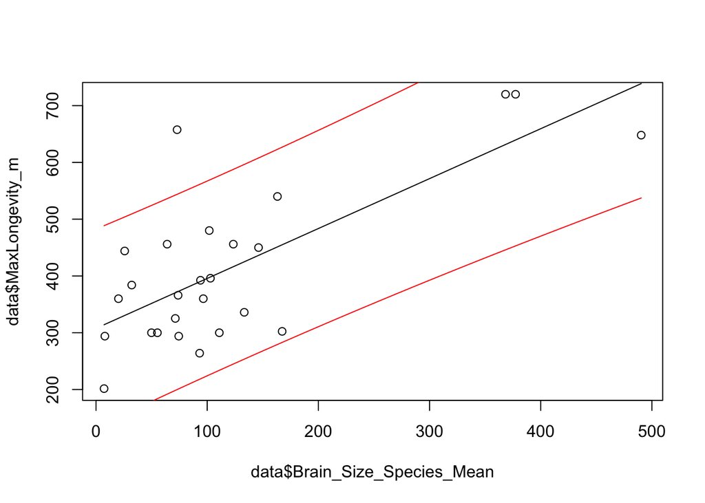

```r
v <- seq(from = min(data$Brain_Size_Species_Mean), to = max(data$Brain_Size_Species_Mean), length.out = 100)
m <- lm(MaxLongevity_m ~ Brain_Size_Species_Mean, data = data)
ci <- predict(m, newdata = data.frame(Brain_Size_Species_Mean = v), interval = "confidence", level = 0.90)
pi <- predict(m, newdata = data.frame(Brain_Size_Species_Mean = v), interval = "prediction", level = 0.90)

#cannot figure out how to do it with ggplot so doing it with general plot function
plot(data$Brain_Size_Species_Mean, data$MaxLongevity_m)
lines(v, ci[, 1], col = "black")
lines(v, pi[, 2], col = "red")
lines(v, pi[, 3], col = "red")
```

> AZ: I believe that you should have two sets of additional lines here, one for CI and one for PI>. I think that the simplest way to do this is to add CI upper, CI lower, PI upper, and PI lower as columns in your dataframe and then graph them using geom_line().

For model 2:

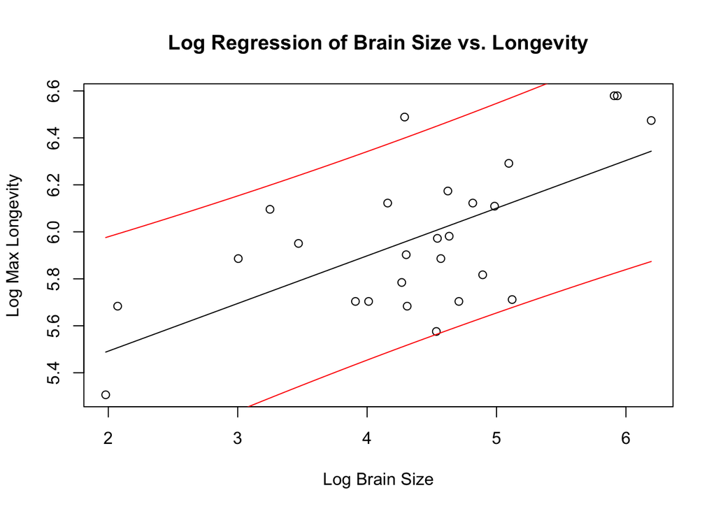

```r
data$log_Brain_Size <- log(data$Brain_Size_Species_Mean)
data$log_Longevity <- log(data$MaxLongevity_m)
m2 <- lm(log_Longevity ~ log_Brain_Size, data = data)
v_log <- seq(from = min(data$log_Brain_Size), to = max(data$log_Brain_Size), length.out = 100)

ci <- predict(m2, newdata = data.frame(log_Brain_Size = v_log), interval = "confidence", level = 0.90)
pi <- predict(m2, newdata = data.frame(log_Brain_Size = v_log), interval = "prediction", level = 0.90)

plot(data$log_Brain_Size, data$log_Longevity,
     xlab = "Log Brain Size",
     ylab = "Log Max Longevity",
     main = "Log Regression of Brain Size vs. Longevity")
lines(v_log, ci[, 1], col = "black")
lines(v_log, pi[, 2], col = "red")
lines(v_log, pi[, 3], col = "red")
```

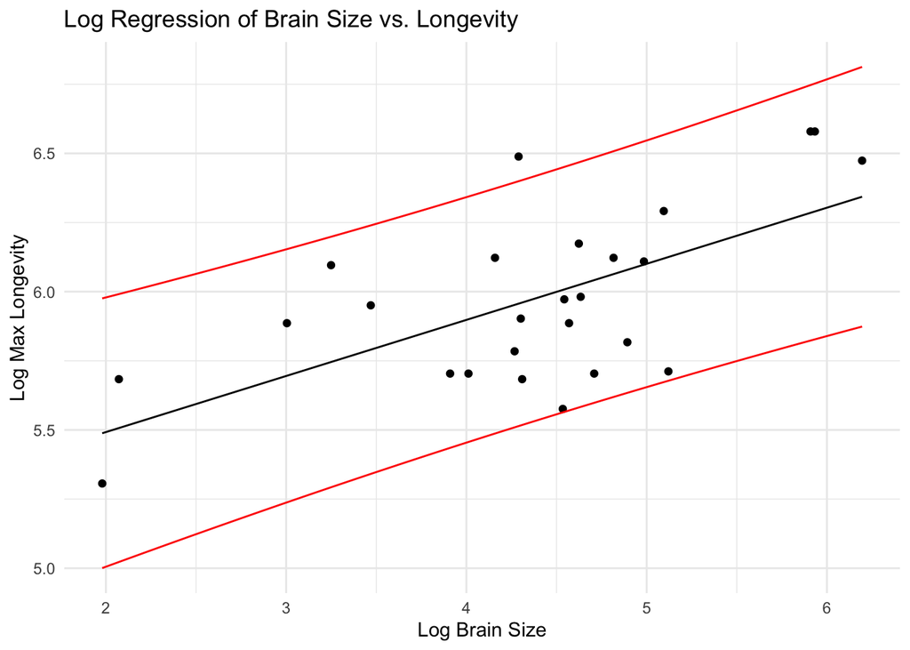

```r
#is this how i could do this with ggplot? offered an alternative that looks more similar to how we did it in module 12
ci_df <- as.data.frame(ci)
pi_df <- as.data.frame(pi)

# Rename columns to prevent duplication
colnames(ci_df) <- c("fit", "ci_lwr", "ci_upr")
colnames(pi_df) <- c("fit_pred", "pi_lwr", "pi_upr")

# Combine into a single data frame
pred_df <- data.frame(log_Brain_Size = v_log, ci_df, pi_df)

# Plot using ggplot2
ggplot(data, aes(x = log_Brain_Size, y = log_Longevity)) +
  geom_point() +
  geom_line(data = pred_df, aes(x = log_Brain_Size, y = fit), color = "black") +
  geom_line(data = pred_df, aes(x = log_Brain_Size, y = pi_lwr), color = "red") +
  geom_line(data = pred_df, aes(x = log_Brain_Size, y = pi_upr), color = "red") +
  labs(x = "Log Brain Size", y = "Log Max Longevity",
       title = "Log Regression of Brain Size vs. Longevity") +
  theme_minimal()
```

I offered two different methods for the second model (the log one) for creating my confidence interval (one with plot and the other with ggplot). i’m open to any suggestions if anyone has any ideas on how to make these plots look better/more similar to the ones we see in the modules. - I also can’t tell if the lines are straight

## Part 4:

Produce a point estimate and associated 90 percent PI for the longevity of a species whose brain weight is 800 gm. Do you trust the model to predict observations accurately for this value of the explanatory variable? Why or why not?

```r
#for longevity ~ brain size
p1 <- predict(model1, newdata = data.frame(Brain_Size_Species_Mean = 800), interval = "prediction", level = 0.90)
p1
```

```
##        fit     lwr      upr
## 1 1010.875 751.631 1270.119
```

```r
#for the log
p2 <- predict(model2, newdata = data.frame(brain_log = 800), interval = "prediction", level = 0.90)
p2
```

```
##         fit      lwr      upr
## 1  5.879581 5.435127 6.324035
## 2  5.900212 5.456443 6.343982
## 3  5.488072 5.000426 5.975719
## 4  5.956641 5.513874 6.399408
## 5  5.952141 5.509341 6.394941
## 6  5.960662 5.517918 6.403406
## 7  5.959129 5.516377 6.401881
## 8  5.745614 5.292652 6.198576
## 9  5.695912 5.238056 6.153767
## 10 6.343229 5.873721 6.812737
## 11 6.024435 5.581181 6.467688
## 12 6.013449 5.570400 6.456498
## 13 6.008060 5.565093 6.451027
## 14 5.930082 5.487002 6.373161
## 15 6.026515 5.583217 6.469812
## 16 6.006391 5.563447 6.449334
## 17 6.285171 5.823241 6.747100
## 18 6.125214 5.677846 6.572583
## 19 6.120023 5.672965 6.567082
## 20 6.097680 5.651834 6.543525
## 21 6.290083 5.827558 6.752609
## 22 5.506794 5.022406 5.991182
## 23 6.041718 5.598046 6.485391
## 24 6.063493 5.619123 6.507863
## 25 6.079029 5.634045 6.524012
## 26 5.790296 5.340944 6.239649
```

```r
new_value <- log(800)  # Log-transform the brain weight

# Compute prediction interval
pred_800 <- predict(m2, newdata = data.frame(log_Brain_Size = new_value), interval = "prediction", level = 0.90)

# Transform back to the original scale
exp(pred_800)
```

```
##        fit      lwr      upr
## 1 627.9747 386.6173 1020.007
```

I think what I wrote above is correct, but why is it giving me all of these values as outputs

> AZ: You can fix the output by replacing “brain” in the “newdata =” section with the existing column name “Brain_Size_Species_Mean,” as I have here. I don’t think that you need to give a log point estimate as well, so that should simplify things a lot!

**Looking at your two models, which do you think is better? Why?** - when asking the model to make predictions for large values that exceed the range for the majority of points in the longevity vs. brain size normal regression, i am not entirely sure that i trust its capacity to predict these values. the log transformed data appears much more evenly distributed and for that reason i trust the log plot/prediction to better capture my data.

> AZ: Overall, your code looks very good! I think that most of the issues that you had were simply due to minor mistakes early on in the process being magnified throughout, like the removal of the NAs mentioned above. Our results look fairly different, but that’s sort of to be expected when you’re dealing with such open-ended tasks that can be completed in many different ways. Your excellent annotation was very helpful in figuring out how portions of your code corresponded to mine and vice versa.